# Numerical Integration

Yuji Saikai ysaikai@unimelb.edu.au School of Mathematics and Statistics The University of Melbourne

These notes are based on Chapter 11 of Jones, O., Maillardet, R., & Robinson, A. (2009). *Introduction to scientific programming and simulation using R*. CRC Press.

# Introduction

A definite integral $\int_a^b f(x)dx$ is easy to compute if we can find an antiderivative $F$ such that $F'(x) = f(x)$ because $\int_a^b f(x)dx = F(b)-F(a)$. Unfortunately, for many functions, it is impossible to write down an antiderivative in a closed form. This is a key motivation for numerical integration, which could provide good approximations of definite integrals. For example, the cumulative distribution function (CDF) of the standard normal distribution
$$\Phi(z) =
\int_{-\infty}^z\frac{1}{\sqrt{2\pi}}e^{-x^2/2}dx$$
is commonly computed via numerical integration. R has a built-in `pnorm` for $\Phi$ and, for example, the following is a good approximation of $\Phi(1.96)$.

```r
pnorm(1.96)
```

```
## [1] 0.9750021
```

A general strategy in both analytical and numerical mathematics is *when a function is too complex to handle, we approximate it by simple functions*. However, there is a key difference between two realms. In analytical integration, an integral is defined as a limit. So, it usually does not matter whether we approximate the integrand by functions or constant values. In numerical integration, on the other hand, we always have to settle for finite granularity, so the choice of simple functions affects the performance of approximation.

In these notes, we consider linear and quadratic approximations. Specifically, the following are three methods in ascending order of sophistication:

- Trapezoidal rule
- Simpson’s rule
- Adaptive quadrature

> These are **deterministic** methods for numerical integration. In contrast, Monte Carlo integration is a class of **stochastic** methods.

A test problem is to integrate $f(x) = x\sin(x)+5$ over $[0,3\pi]$, which can be analytically computed using integration by parts.
$$\begin{align}
\int_0^{3\pi} x\sin(x)+5 dx
&= \int_0^{3\pi} x\sin(x) dx + \int_0^{3\pi} 5 dx\\
&= \left( -x\cos(x)\Bigr\rvert_0^{3\pi} + \int_0^{3\pi}\cos(x)dx
\right) + 15\pi\\
&= 18\pi\\
&\approx 56.5486677646
\end{align}$$

```r
f <- function(x) x*sin(x)+5
integrate(f, 0, 3*pi) # R built-in function
```

```
## 56.54867 with absolute error < 8e-12
```

# Trapezoidal rule

Given a finite set of subintervals, the trapezoidal rule approximates the area under $y=f(x)$ by the finite sum of trapezoid areas, which are easy to compute. For example, using $n=6$ subintervals,

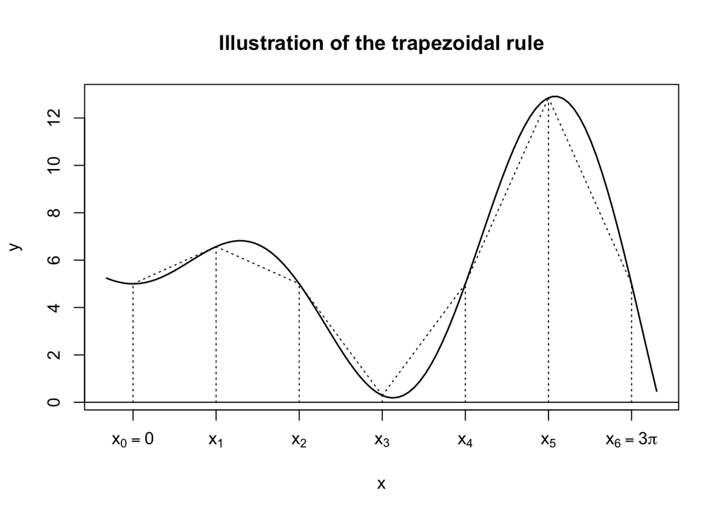

```r
curve(x*sin(x)+5, xaxt="n", lwd=1.5, from=-.5, to=9.9, ylab="y")
abline(h=0)
title("Illustration of the trapezoidal rule")
x <- seq(0, 3*pi, .5*pi)
# How can we generate these expressions using a loop?
letters <- c(expression(x[0]==0), expression(x[1]), expression(x[2]),
             expression(x[3]), expression(x[4]), expression(x[5]),
             expression(x[6]==3*pi))
axis(1, at=x, labels=letters)
from_x <- c(0, .5*pi, pi, 1.5*pi, 2*pi, 2.5*pi, 3*pi)
from_y <- rep(0,7)
to_x <- from_x
to_y <- sapply(from_x, function(x) x*sin(x)+5)
segments(from_x, from_y, to_x, to_y, lty=3)

from_x <- from_x[-length(from_x)]
from_y <- to_y[-length(to_y)]
to_x <- to_x[-1]
to_y <- to_y[-1]
segments(from_x, from_y, to_x, to_y, lty=3)
```

and using $n=12$ subintervals,

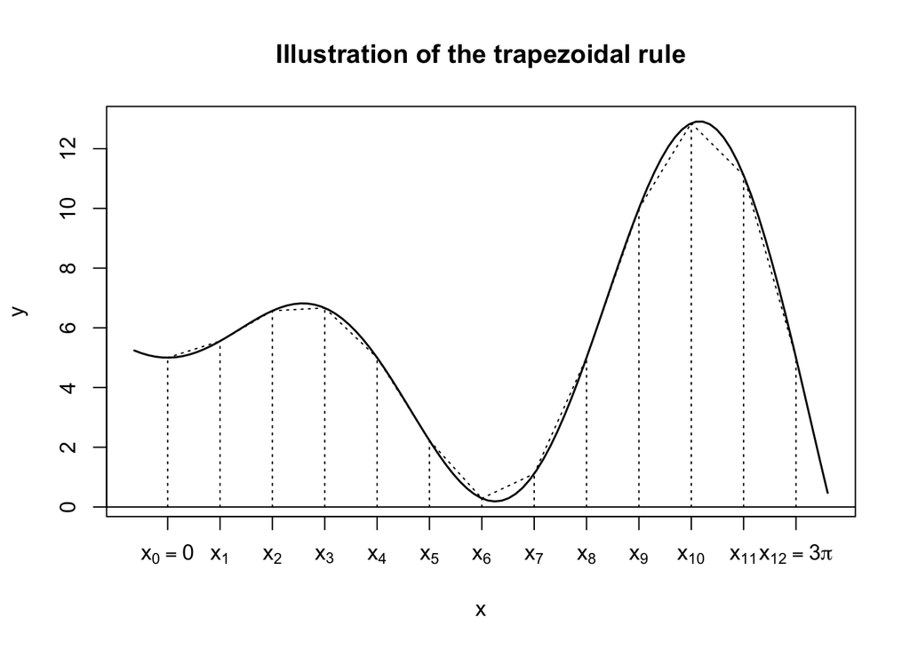

```r
curve(x*sin(x)+5, xaxt="n", lwd=1.5, from=-.5, to=9.9, ylab="y")
abline(h=0)
title("Illustration of the trapezoidal rule")
x <- seq(0, 3*pi, length.out=13)
# How can we generate these expressions using a loop?
letters <- c(expression(x[0]==0), expression(x[1]), expression(x[2]),
             expression(x[3]), expression(x[4]), expression(x[5]),
             expression(x[6]), expression(x[7]), expression(x[8]),
             expression(x[9]), expression(x[10]), expression(x[11]),
             expression(x[12]==3*pi))
axis(1, at=x, labels=letters)
from_x <- seq(0, 3*pi, length.out=13)
from_y <- rep(0,13)
to_x <- from_x
to_y <- sapply(from_x, function(x) x*sin(x)+5)
segments(from_x, from_y, to_x, to_y, lty=3)

from_x <- from_x[-length(from_x)]
from_y <- to_y[-length(to_y)]
to_x <- to_x[-1]
to_y <- to_y[-1]
segments(from_x, from_y, to_x, to_y, lty=3)
```

In general, suppose we try to approximate $\int_a^b f(x)dx$ using $n$ subintervals. Let $h$ denote the length of each subinterval, i.e. $h = (b-a)/n$. Then, the sum of all trapezoid areas $T(n)$ is given by:
$$\begin{align}
T(n) &=
\frac{h}{2}(f(x_0)+f(x_1))+\frac{h}{2}(f(x_1)+f(x_2))+\dots+\frac{h}{2}(f(x_{n-1})+f(x_n))\\
&= \frac{h}{2}(f(x_0)+2f(x_1)+2f(x_2)+\dots+2f(x_{n-1})+f(x_n))
\end{align}$$
Since it is a type of [Riemann sum](https://en.wikipedia.org/wiki/Riemann_sum), the approximation improves as $n$ increases.

```r
trapezoid <- function(f, a, b, n) {
  h <- (b - a)/n
  x <- seq(a+h, b-h, by=h)
  T <- h/2*(f(a) + 2*sum(f(x)) + f(b))

  return(T)
}
```

```r
trapezoid(f, 0, 3*pi, 100)
```

```
## [1] 56.54169
```

# Simpson’s rule

As implied by the use of trapezoids, the trapezoidal rule approximates $f$ by a **piece-wise linear** function. Simpson’s rule uses, instead, a **piece-wise quadratic** function for an approximation of $f$. Since a quadratic function $p(x) = ax^2 + bx + c$ has three parameters $(a,b,c)$, three non-collinear points $(u,f(u))$, $(v,f(v))$, and $(w,f(w))$ in $\mathbb{R}^2$ pin down the function through a system of three linear equations. (Without loss of generality, assume $u<v<w$.)

> Collinearity means $(v,f(v)) = t(u,f(u))+(1-t)(w,f(w))$ for $t\in(0,1)$. Can you see its implication for $p(x) = ax^2 + bx + c$?

$$\begin{cases}
au^2 + bu + c = f(u)\\
av^2 + bv + c = f(v)\\
aw^2 + bw + c = f(w)
\end{cases}$$

Solving the system of equations, we get
$$p(x) = f(u)\frac{(x-v)(x-w)}{(u-v)(u-w)} +
f(v)\frac{(x-u)(x-w)}{(v-u)(v-w)} +
f(w)\frac{(x-u)(x-v)}{(w-u)(w-v)} .$$

> Plug in each of three points and see this make sense.

If $u=v-h$ and $w=v+h$, then
$$\begin{align}
p(x) &= f(u)\frac{(x-v)(x-w)}{(u-v)(u-w)} +
f(v)\frac{(x-u)(x-w)}{(v-u)(v-w)} +
f(w)\frac{(x-u)(x-v)}{(w-u)(w-v)}\\
&= f(u)\frac{(x-v)(x-v-h)}{(-h)(-2h)} +
f(v)\frac{(x-v+h)(x-v-h)}{(h)(-h)} +
f(w)\frac{(x-v+h)(x-v)}{(2h)(h)}\\
&= \frac{f(u)}{2h^2}(x-v)(x-v-h) -
\frac{f(v)}{h^2}(x-v+h)(x-v-h) + \frac{f(w)}{2h^2}(x-v+h)(x-v)\\
&= (x-v)^2\left(\frac{f(u)}{2h^2} - \frac{f(v)}{h^2} +
\frac{f(w)}{2h^2}\right) +
(x-v)\left(\frac{f(u)}{2h^2}(-h) + \frac{f(w)}{2h^2}h\right) +
\frac{f(v)}{h^2}h^2\\
&= (x-v)^2\left(\frac{f(u)}{2h^2} - \frac{f(v)}{h^2} +
\frac{f(w)}{2h^2}\right) +
(x-v)\left(-\frac{f(u)}{2h} + \frac{f(w)}{2h}\right) + f(v)
\end{align}$$

As a result, we get the following integral.
$$\begin{align}
\int_u^w p(x)dx &= \int_{v-h}^{v+h}
\left[(x-v)^2\left(\frac{f(u)}{2h^2} - \frac{f(v)}{h^2} +
\frac{f(w)}{2h^2}\right) +
(x-v)\left(-\frac{f(u)}{2h} +
\frac{f(w)}{2h}\right) + f(v) \right]dx\\
&=
\Biggl\lvert\frac{(x-v)^3}{3}\left(\frac{f(u)}{2h^2} - \frac{f(v)}{h^2}
+ \frac{f(w)}{2h^2}\right) +
\frac{(x-v)^2}{2}\left(\frac{f(u)}{2h^2}(-h)+\frac{f(w)}{2h^2}h\right)
+ xf(v) \Biggr\rvert_{v-h}^{v+h}\\
&= \frac{2h^3}{3}\left(\frac{f(u)}{2h^2} -
\frac{f(v)}{h^2} + \frac{f(w)}{2h^2}\right) + 2hf(v)\\
&= \frac{h}{3}(f(u)+4f(v)+f(w))
\end{align}$$

This is an approximation of $\int_u^w f(x)dx$ using a single quadratic function. Now, we can

1. divide the whole integration region into $n$ number of subintervals where $n$ is **even**,
2. repeat the above integration $n/2$ times, and
3. get an approximation $S(n)\approx\int_a^b f(x)dx$ as the sum of $n/2$ integrals.

$$\begin{align}
S(n) &= \frac{h}{3}(f(x_0)+4f(x_1)+f(x_2)) +
\frac{h}{3}(f(x_2)+4f(x_3)+f(x_4)) +
\dots \\
&\qquad + \frac{h}{3}(f(x_{n-2})+4f(x_{n-1})+f(x_{n}))\\
&=
\frac{h}{3}(f(x_0)+4f(x_1)+2f(x_2)+4f(x_3)+\dots+4f(x_{n-1})+f(x_{n}))
\end{align}$$

Notice that the function values for even points (except $n$) get $2$ as each of them is used for two adjacent subintervals.

Let’s apply Simpson’s rule to the test problem.

```r
simpson_n <- function(f, a, b, n) {
  n <- max(2*(n%/%2), 2) # %/% (integer division) for even n >= 2
  h <- (b - a)/n
  y.a <- f(a)
  y.b <- f(b)
  x <- seq(a+h, b-h, by=h)
  y <- f(x)
  coeffs <- c(rep(c(4,2), n/2-1), 4) # coefficients 4,2,...,4,2,4
  S <- h/3*(y.a + sum(coeffs*y) + y.b) # coeffs*y: component-wise product

  return(S)
}
```

```r
simpson_n(f, 0, 3*pi, 30)
```

```
## [1] 56.54918
```

Simpson with $n=30$ works better than Trapezoid with $n=100$.

## How large $n$ should be

When using Simpson’s rule in practice, we need to choose $n$ that leads to a reasonably accurate approximation. Suppose that $f$ is Riemann integrable (i.e., continuous and bounded almost everywhere). Let $I = \int_a^b f(x)dx$. Also, let $S(n)$ be the approximate integral via Simpson’s rule using $n$ subintervals. Then, we have
$$\lim_{n\to\infty}|S(n) - I| = 0.$$
Now, by the triangle inequality, we have
$$\begin{align}
|S(2n)-S(n)| &= |S(2n)-I-S(n)+I|\\
&= |S(2n)-I+(-(S(n)-I))|\\
&\leq |S(2n)-I|+|-(S(n)-I)|\\
&= |S(2n)-I|+|S(n)-I|,
\end{align}$$
which implies
$$\lim_{n\to\infty}|S(2n)-S(n)| = 0.$$
$|S(2n)-S(n)|$ can be seen as an improvement after doubling the number of subintervals. Thus, given some small $\epsilon$, we can use $|S(2n)-S(n)|\leq\epsilon$ as a stopping criterion for doubling $n$. Now, modify the above Simpson’s rule so that, given $\epsilon$, we can determine a large enough $n$.

Observe that we increase $n$ by a factor of $2$ each time, so that we can reuse the previous $n+1$ function values. In practice, evaluation of $f$ is the most expensive operation when doing numerical integration. If we increased $n$ by an arbitrary even number, then two sets of evaluation points before and after the increase will likely be misaligned, so we will have to re-calculate $f$ at all points. In contrast, if we double $n$, we can reuse all the existing $n+1$ values at the original set of points, and simply need to evaluate $f$ at $n$ in-between points.

```r
simpson <- function(f, a, b, tol) {
  n <- 2
  h <- (b - a)/n
  y.a <- f(a)
  y.b <- f(b)
  x <- seq(a+h, b-h, by=h)
  y <- f(x)
  coeffs <- c(rep(c(4,2), n/2-1), 4)
  S <- h/3*(y.a + sum(coeffs*y) + y.b)
  S.old <- S + 2*tol # to ensure to loop at least once

  while (abs(S - S.old) > tol) {
    S.old <- S
    y.old <- y
    n <- 2*n
    h <- h/2
    y <- rep(0, n-1) # initialisation
    y[seq(2, n-2, by=2)] <- y.old # reused values
    x <- seq(a+h, b-h, by=2*h)
    y[seq(1, n-1, by=2)] <- f(x) # new values
    coeffs <- c(rep(c(4,2), n/2-1), 4)
    S <- h/3*(y.a + sum(coeffs*y) + y.b)
  }

  return(list("S"=S, "Number of intervals"=n))
}
```

```r
simpson(f, 0, 3*pi, 1e-4)
```

```
## $S
## [1] 56.54867
##
## $`Number of intervals`
## [1] 128
```

# Adaptive quadrature

Evenly dividing the integration region is intuitive and will likely work well if we have computational capacity for large $n$. If not, we can divide the region adaptively and achieve the same level of performance with smaller $n$. A typical situation in which adaptivity makes difference is that the function to integrate has varying curvatures. Adaptive quadrature is *Simpson’s rule with subinterval length $h$ locally adapted*. The key idea is that:

- Divide each subinterval in half.
- Subinterval division occurs only where needed.
- Need is determined **locally** by examining whether an improvement $|S(4)-S(2)|$ is still large for **each subinterval**.

> To avoid distraction, here, we loosely use the word **curvature**, whose formal definition can be found [here](https://tutorial.math.lamar.edu/classes/calciii/curvature.aspx). Since we fit a quadratic function at each subregion, what matters is neither the steepness nor the varying slopes per se; in the end, a qudratic function has constantly varying slopes.

Here is the algorithm. Do the following for **each subinterval** that is not yet marked “terminated”.

1. Compute $S(2)$ using Simpson’s rule with $n=2$.
2. Compute $S(4)$ using Simpson’s rule with $n=4$.
3. If an improvement $|S(4)-S(2)|$ is still large, subdivide it in half; otherwise, terminate subdivision of **that subinterval**.

Continue until all subintervals are marked terminated.

Since a size of improvement depends on the shape of the function over a subinterval, subdivision in one region where the curvature changes rapidly may stop only for a small subinterval while subdivision in another region where the curvature does not change much may stop even for a large subinterval. This results in varying lengths of subintervals.

This type of algorithms is efficiently and naturally implemented using a recursive function because, compared to “linear” processes implemented in loops, the halving process is more “organic” where a single subinterval spawns two subintervals, each of which spawns two… The price to pay is difficulty in following the flow of the process; it is not easy to keep track of the order of subdivisions and terminations.

Let’s apply adaptive quadrature to $f(x) = -4x\log(x)$ over $(0,1]$, whose curvature changes rapidly near the origin as $f'(x) = -4(\log(x)+1) \to \infty$.

> Using $u=\log(x)$ substitution and integration by parts, we can analytically get $\int_0^1f(x)dx=1$.

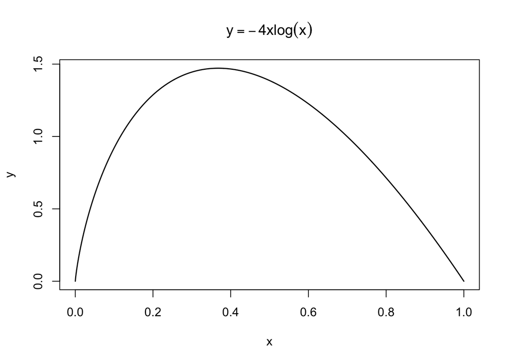

```r
aq <- function(f, a, b, tol) {
  # Initialisation
  c = (a + b)/2
  h <- (b - a)/2
  f.a <- f(a)
  f.b <- f(b)
  f.c <- f(c)
  ## X: History of evaluation points. Not part of the algorithm
  ## but used only for generating the figure.
  X <- c(a, b, c)
  S2<- h/3*(f.a + 4*f.c + f.b)

  # Call the recursive function aq.recur
  re <- aq.recur(f, a, b, c, f.a, f.b, f.c, S2, tol, X)

  return(re)
}
```

```r
# Compute S4
aq.recur <- function(f, a, b, c, f.a, f.b, f.c, S2, tol, X) {
  h <- (b - a)/4
  f.l <- f(a + h) # midpoint of the left
  f.r <- f(b - h) # midpoint of the right
  X <- c(X, a+h, b-h) # 2 more evaluation points
  I.l <- h/3*(f.a + 4*f.l + f.c) # integral over the left
  I.r <- h/3*(f.c + 4*f.r + f.b) # integral over the right
  S4 <- I.l + I.r

  if (abs(S4 - S2) > tol) {
    re.l <- aq.recur(f, a, c, a+h, f.a, f.c, f.l, I.l, tol, X)
    X <- re.l[[2]]
    re.r <- aq.recur(f, c, b, b-h, f.c, f.b, f.r, I.r, tol, X)
    X <- re.r[[2]]
    S4 <- re.l[[1]] + re.r[[1]]
  }

  return(list(S4, X))
}
```

```r
re <- aq(f, 0, 1, 1e-5)
I.aq <- re[[1]]
I.aq
```

```
## [1] 0.9999979
```

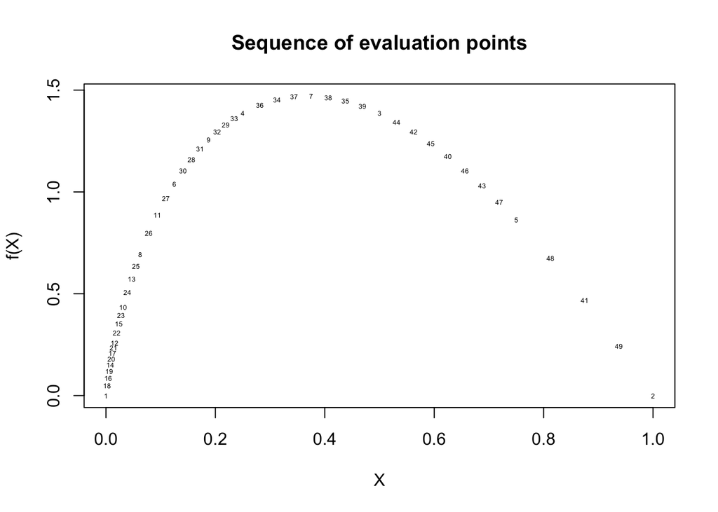

The number of evaluations is $49$, which is unevenly distributed over the region. As you can see, the function is evaluated more where the curvature changes rapidly. In addition, given the position of `X <- c(X, a+h, b-h)` in `aq.recur`, does this order of evaluations make sense?

In contrast, to achieve the same level of accuracy using Simpson’s rule, we need the following number of subintervals.

```r
# To search for n that makes simpson_n comparable with aq
bisec_int <- function(method, n.l, n.r=1e4) {
  I <- simpson_n(f, 0, 1, n.l)

  # n.r-n.l<2 as a stopping criterion
  while ((n.r - n.l) >= 2) {
    n <- ceiling((n.r+n.l)/2)
    I <- method(f, 0, 1, n)

    if (isTRUE(all.equal(I, I.aq))) {
      break
    } else if ((I - I.aq) > 0) {
      n.r <- n
    } else {
      n.l <- n
    }
  }

  return(n.r)
}

n <- bisec_int(simpson_n, 2)
n
```

```
## [1] 384
```

This is 336 more evaluations than that used by the adaptive quadrature.

> Number of function evaluations is equal to number of subintervals + 1.